# PSTAT 220A Section 01

Jaxon Stuhr

September 27, 2022

**Note:** Today’s material is from tutorials by [Coding Club](https://ourcodingclub.github.io/tutorials/rmarkdown/) and [R Studio](https://rmarkdown.rstudio.com/index.html).

## R Markdown

R Markdown is a file format for writing reproducible, dynamic reports with R. Use it to embed R code and results into slideshows, pdfs, html documents, word files and more. A file is a simple plain text file with three types of content: metadata, text and code chunks, like the document below.

**Header**: at the top of any RMarkdown script is a header section. By default this includes a title, author, date and the file type you want to output to. Many other options are available for different functions and formatting, see [here](https://bookdown.org/yihui/rmarkdown/html-document.html) for options and [here](https://bookdown.org/yihui/rmarkdown/pdf-document.html) for options. Rules in the header section will alter the whole document.

**Code Chunks**: below the header is the space where you will write your code, accompanying explanation and any outputs. Codes included in your document should be enclosed by chunk delimiters. When you render your file, R Markdown will run each code chunk and embed the results beneath the code chunk in your final report.

## Formatting Text

### Basic Formatting

I only list some syntax here. See [R Markdown Cheatsheets](https://rmarkdown.rstudio.com/lesson-15.html) for more syntax.

- **Paragraph Breaks**: To insert a break between paragraphs, include a single completely blank line. To force a line break, put two blank spaces at the end of a line.
- **Headers**: The character at the beginning of a line means that the rest of the line is interpreted as a section header. The number of ’s at the beginning of the line indicates whether it is treated as a section, sub-section, sub-sub-section, etc. of the document.
- **Italics and Boldface**: Text to be *italicized* goes inside a single set of underscores or asterisks. Text to be **boldfaced** goes inside a double set of underscores or asterisks.

### Inline Code

Code output can also be seamlessly incorporated into the text, using **inline code**. This is code not set off on a line by itself, but beginning with and ending with . Using inline code is how this document knows that $1+2+\cdots+100$ equals to 5050.

### Mathematical Formula

R Markdown gives you the syntax to render complex mathematical formulas and derivations, and have them displayed very nicely. The syntax is same as . And like code, the math can either be inline or set off.

Inline mathematical formula is marked off with a pair of dollar signs (), such as $\bar{X}=\frac{1}{n}\sum_{j=1}^nX_j$. Mathematical displays are marked off with and , as in

```
\[
\bar{X}=\frac{1}{n}\sum_{j=1}^nX_j
\]
```

$$\bar{X}=\frac{1}{n}\sum_{j=1}^nX_j.$$

You can also use environments, such as , , and etc. from . See section 3.10 from [*The Not So Short Introduction to*](https://mirror.las.iastate.edu/tex-archive/info/lshort/english/lshort.pdf) for list of mathematical symbols.

## Inserting Figures

Inserting a graph generated by into RMarkdown is relatively easy. By default, RMarkdown will place graphs by maximizing their height, while keeping them within the margins of the page and maintaining aspect ratio. And to manually set the figure dimensions, you can insert an instruction into the curly braces:

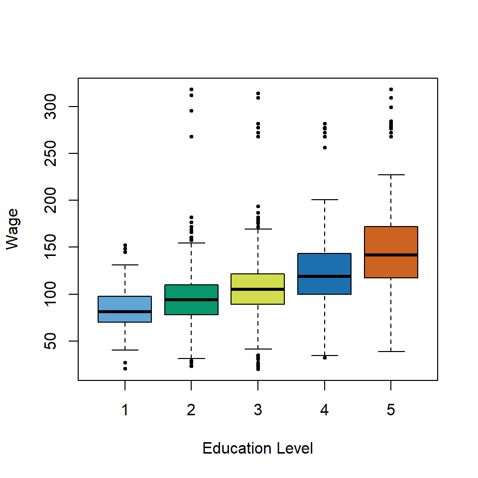

```r
library(ISLR)
data("Wage")
boxplot(wage~unclass(education),data=Wage,pch=19,cex=0.5,
        col=c("#5fa5d6","#08966c","#d2dd4e","#1d70b0","#cc6320"),
        xlab="Education Level",ylab="Wage")
```

You can also insert a local image by the following syntax:

```
 ![](path/to/smallorb.png)
```

However, it is not easy to adjust the location and parameters of a figure by the above code. I would recommend you to use the picture environment from .

## Inserting Tables

Tables are important in statistical reports. There are several ways to insert tables in your files. And we first create the following data frame, and then use it for illustration.

```r
Plant <- c("A", "B", "C")
Temp. <- c(20, 20, 20)
Growth <- c(0.65, 0.95, 0.15)
da <- data.frame(Plant, Temp., Growth)
```

You can directly print the content of a data frame with the following syntax.

```r
da
```

```
##   Plant Temp. Growth
## 1     A    20   0.65
## 2     B    20   0.95
## 3     C    20   0.15
```

However, this table looks a bit messy.

The simplest table formatting function is function in package. The first argument tells to make a table out of the target data frame and that numbers should have at most two digits.

```r
kable(da, digits = 2)
```

| Plant | Temp. | Growth |
| --- | --- | --- |
| A | 20 | 0.65 |
| B | 20 | 0.95 |
| C | 20 | 0.15 |

See [*Create Awesome Table with and*](https://haozhu233.github.io/kableExtra/awesome_table_in_pdf.pdf) for more details and examples.

### Manually creating tables using markdown syntax

You can also manually create small tables using markdown syntax. For example:

```
| Plant | Temp. | Growth |
|:------|:-----:|-------:|
| A     | 20    | 0.65   |
| B     | 20    | 0.95   |
| C     | 20    | 0.15   |
```

will create something that looks like this:

| Plant | Temp. | Growth |
| --- | --- | --- |
| A | 20 | 0.65 |
| B | 20 | 0.95 |
| C | 20 | 0.15 |

The tells markdown that the line above should be treated as a header and the lines below should be treated as the body of the table. Text alignment of the columns is set by the position of .

**Get your hand dirty, and try to write your homework with R Markdown!**